### Optimization for Data Science

### M2 MIAGE & MIAGE ID Apprentissage, 2026-2027

# Illustration notebook - Advanced gradient methods

This Jupyter notebook was kindly provided by [Clément W. Royer](https://ligm.univ-eiffel.fr/~croyer/), who taught this course in previous years; it may have been slightly adapted since. The current version and the one with solutions can be found [here](https://bastiencavarretta.github.io/teachings/2026-optimization-data-science/)

#### Preliminary remarks

This lab session aims at illustrating several advanced aspects of gradient descent. More precisely, we aim at illustrating the interest of accelerated methods in a convex setting, and at studying the behavior of gradient descent in a nonconvex setting.

*Note: All blocks of this notebook are built to be run sequentially. In particular, the block below should be executed before going any further.*

```python
# Preamble: useful toolboxes, librairies, functions, etc.

# Display
%matplotlib inline
import matplotlib.pyplot as plt

from math import sqrt # Square root
from math import ceil # Ceil integer operator
from math import log # Logarithm function

# NumPy - Matrix and vector structures
import numpy as np # NumPy library
from numpy.random import multivariate_normal, randn, uniform, choice # Probability distributions

# SciPy - Efficient mathematical calculation
from scipy.linalg import norm # Euclidean norm
from scipy.linalg import toeplitz # Toeplitz matrices
from scipy.linalg import svdvals # Singular value decomposition
from scipy.linalg import qr # QR decomposition from linear algebra
from scipy.optimize import check_grad # Check derivatives
from scipy.optimize import fmin_l_bfgs_b # Efficient method for minimization
```

# Part 1 - Gradient methods with momentum

In this part of the notebook, we compare the basic gradient descent method with accelerated techniques, that leverage information from the previous iteration.

## 2.1 Quadratic problems and gradient descent

As in the first lab session, we consider the strongly convex problem

$$ \mathrm{minimize}_{\mathbf{w} \in \mathbb{R}^d}\ \frac{1}{2}\mathbf{w}^T \mathbf{C} \mathbf{w}, $$

where $\mathbf{C}$ is symmetric positive definite with eigenvalues between $\mu$ and $L$. It follows that the function is $\mu$-strongly convex and $\mathcal{C}^{1,1}_L$.

```python
# Defining two quadratic problems through (random) matrices

# Problem size
d=100

# Lipschitz constant
L=1

# Strong convexity constant
mu=0.01

# Fix random seed for reproducibility
np.random.seed(1)

# Generate a random orthogonal matrix Q
M = np.random.multivariate_normal(np.zeros(d),np.identity(d),size=d)
Q,R = qr(M) # Q is orthogonal by definition of the QR factorization

# Generate random eigenvalues between mu and L (procedure used for a better spread of the eigenvalues)
D = np.random.uniform(mu,L,d)
D = 10.**D
D = (D-min(D))/(max(D)-min(D))
D = mu+(L-mu)*D

# Produce matrix C
C = Q.T @ np.diag(D) @ Q
```

```python
def gd_quad(w0,C,stepsize,n_iter=100, verbose=False):
    """
        A code for gradient descent on quadratic functions.

        Inputs:
            w0: Initial vector
            C: Square matrix of same
            stepsize: Value of the (constant) stepsize
            n_iter: Number of iterations
            verbose: Boolean value indicating whether the outcome of every iteration should be displayed

        Outputs:
            w_output: Final iterate of the method
            objvals: History of function values (output as a Numpy array of length n_iter+1)

    """

    ############
    # Initial step: Compute and plot some initial quantities

    # objective history
    objvals = []

    # Initial value of current iterate
    w = w0.copy()

    # Initialize iteration counter
    k=0

    # Current value for the objective function
    obj = 0.5*w.dot(C.dot(w))

    objvals.append(obj);

    g = C.dot(w)

    # Plot the initial values if asked to
    if verbose:
        print("Gradient Descent:")
        print(' | '.join([name.center(8) for name in ["iter", "fval"]]))
        print(' | '.join([("%d" % k).rjust(8),("%.2e" % obj).rjust(8)]))

    ####################
    # Main loop
    while (k < n_iter):


        # Select the stepsize and perform the update
        w[:] = w - stepsize * g

        # Compute the new gradient
        g = C.dot(w)

        # Compute the new objective value
        obj = 0.5*w.dot(g)


        objvals.append(obj)

        # Plot relevant information if asked to
        if verbose:
            print(' | '.join([("%d" % k).rjust(8),("%.2e" % obj).rjust(8)]))

        # Increment the iteration count
        k += 1

    # End main loop
    ######################

    # Output
    w_output = w.copy()
    return w_output, np.array(objvals)
```

## 1.2 Momentum-based methods

The simplest variant of gradient descent based on acceleration or momentum is the **heavy-ball** method due to Polyak. Given $\mathbf{w}_0 \in \mathbb{R}^d$ and $\mathbf{w}_{-1}=\mathbf{w}_0$, the $k$th iteration of the heavy-ball method can be written as follows: $$ \mathbf{w}_{k+1} = \mathbf{w}_k - \alpha_k \nabla f(\mathbf{w}_k) + \beta_k (\mathbf{w}_k-\mathbf{w}_{k-1}) \qquad \forall k \ge 0, $$ where $\alpha_k >0$ and $\beta_k >0$. In this notebook, we will choose these parameters to be constant.

We also consider the accelerated gradient method (also called Nesterov's method)

$$ \mathbf{w}_{k+1} = \mathbf{w}_k - \alpha_k \nabla f(\mathbf{w}_k+\beta_k (\mathbf{w}_k-\mathbf{w}_{k-1})) + \beta_k (\mathbf{w}_k-\mathbf{w}_{k-1}) \qquad \forall k \ge 0, $$

This method is often written under the form of a double recursion. Starting from $\mathbf{z}_0=\mathbf{w}_0,t_0=0$, the method generates two vector sequences $\{\mathbf{w}_{k},\mathbf{z}_k\}$ through the following recursion:

$$ \left\{ \begin{array}{lll} \mathbf{w}_{k+1} &= &\mathbf{z}_k - \alpha_k \nabla f(\mathbf{z}_k) \\ \mathbf{z}_{k+1} &= &\mathbf{w}_{k+1} + \beta_{k+1}(\mathbf{w}_{k+1}-\mathbf{w}_k). \end{array} \right. $$

In this recursion, the value $\alpha_k>0$ is a stepsize. For an arbitrary convex function, the $\{\beta_k\}$ sequence is computed via the following formula: $$ t_0 = 0, \quad \forall k \ge 0, \left\{ \begin{array}{lll} t_{k+1} &= &\tfrac{1}{2} (1+ \sqrt{1+4 t_{k}^2}), \\ \beta_k &= &\frac{t_k-1}{t_{k+1}} \end{array} \right. $$ while for a $\mu$-strongly convex function, the constant value $\beta_k = \tfrac{\sqrt{L}-\sqrt{\mu}}{\sqrt{L}+\sqrt{\mu}}$ is used, where $L$ is the Lipschitz constant for the gradient.

The code below implements Polyak's heavy ball method as well as the two variants of Nesterov's method using a constant stepsize.

```python
# Momentum-based methods for quadratic functions
def momentum_quad(w_0,C,stepsize,method="nesterov",momentum=None,n_iter=100,verbose=False):
    """
        A generic code for Polyak's heavy-ball method and Nesterov's accelerated gradient
        variants on quadratic functions.

        Inputs:
            w0: Initial vector
            C: Data matrix
            stepsize: Constant value for the stepsize
            method: Type of acceleration technique that is used
                'heavyball': Heavy-ball method
                'nesterov': Accelerated gradient for convex functions (Nesterov,default)
                'nesterovstrong': Accelerated gradient for strongly convex functions
            momentum: Constant value for the momentum parameter (only used if method!='nesterov')
            n_iter: Number of iterations
            verbose: Boolean value indicating whether the outcome of every iteration should be displayed

        Outputs:
            z_output: Final iterate of the method
            objvals: History of function values in z (output as a Numpy array of length n_iter+1)
    """

    ############
    # Initial step: Compute and plot some initial quantities

    # objective history
    objvals = []


    # Initial value of current and next iterates
    w = w0.copy()
    w_new = w0.copy()
    z = w0.copy() # Extra sequence for momentum

    if method=='nesterov':
        # Initialize parameter sequence
        tk = 0
        tkp1 = 1
        momentum = 0

    # Initialize iteration counter
    k=0

    # Initial objective
    obj = 0.5*z.dot(C.dot(z))
    objvals.append(obj);

    # Plot the initial values if required
    if verbose:
        print("Accelerated Gradient/"+method)
        print(' | '.join([name.center(8) for name in ["iter", "fval"]]))
        print(' | '.join([("%d" % k).rjust(8),("%.2e" % obj).rjust(8)]))

    #######################
    # Main loop
    while (k < n_iter):


        if method=='heavyball':
            # Compute gradient
            g = C.dot(w_new)
            # Compute momentum term and update w
            z[:] = w_new - w
            w[:] = w_new[:]
            # Add momentum step
            w_new[:] = w_new -stepsize*g + momentum*z
        else:
            # Gradient step
            g = C.dot(z)
            w_new[:] = z - stepsize * g
            # Momentum step
            z[:] = w_new + momentum*(w_new-w)
            # Update sequence
            w[:] = w_new[:]


        # Adjusting the momentum parameter if needed
        if method=='nesterov':
            tkp1 = 0.5*(1+sqrt(1+4*(tk**2)))
            momentum = (tk-1)/tkp1
            tk = tkp1

        #### END SECTION TO BE FILLED

        # Compute and plot the new objective value and distance to the minimum
        if method=='heavyball':
            obj = 0.5*w.dot(C.dot(w))
        else:
            obj = 0.5*z.dot(C.dot(z))
        objvals.append(obj)

        # Plot these values if required
        if verbose:
            print(' | '.join([("%d" % k).rjust(8),("%.2e" % obj).rjust(8)]))

        # Increment the iteration counter
        k += 1

    # End loop
    #######################


    # Output
    z_output = z.copy()

    return z_output, np.array(objvals)
```

The script below compares the following four methods on the strongly convex problem:

a) Gradient descent with stepsize $\tfrac{1}{L}$.

b) Heavy-ball method with stepsize $\tfrac{4}{(\sqrt{\mu}+\sqrt{L})^2}$ and momentum parameter $\tfrac{\sqrt{L}-\sqrt{\mu}}{\sqrt{L}+\sqrt{\mu}}$.

c) Nesterov's method with stepsize $\tfrac{1}{L}$ and variable momentum parameter.

d) Nesterov's method with stepsize $\tfrac{1}{L}$ and momentum parameter $\tfrac{\sqrt{L}-\sqrt{\mu}}{\sqrt{L}+\sqrt{\mu}}$.

```
Average function value for GD: 7.158419227085066e-05
Average function value for Heavy Ball 5.1864973155588105e-21
Average function value for Nesterov (convex version) 1.2688414440929472e-07
Average function value for Nesterov (strongly convex version) 5.2673185575488074e-23
```

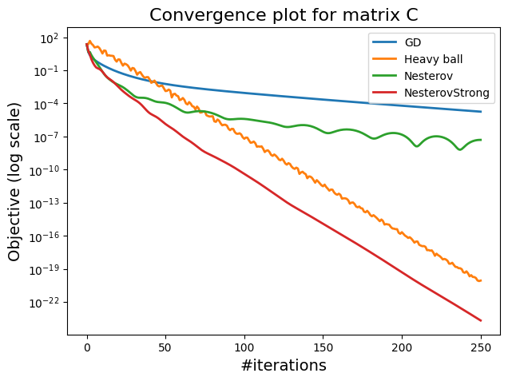

```python
# Implementation - Running all methods with 10 random initial points
nruns=10
nits=250

beta = (sqrt(L)-sqrt(mu))/(sqrt(L)+sqrt(mu))
stepsize_hb = 4/((sqrt(mu)+sqrt(L))**2)

avg_gd = 0
avg_hb = 0
avg_n = 0
avg_ns = 0

for i in range(nruns):
    w0 = randn(d)
    w_gd, obj_gd = gd_quad(w0,C,1/L,nits)
    avg_gd += obj_gd[-1]
    w_hb, obj_hb = momentum_quad(w0,C,stepsize_hb,'heavyball',beta,nits)
    avg_hb += obj_hb[-1]
    w_n, obj_n = momentum_quad(w0,C,1/L,'nesterov',None,nits)
    avg_n += obj_n[-1]
    w_ns, obj_ns = momentum_quad(w0,C,1/L,'nesterovstrong',beta,nits)
    avg_ns += obj_ns[-1]


print('Average function value for GD:',avg_gd/nruns)
print('Average function value for Heavy Ball',avg_hb/nruns)
print('Average function value for Nesterov (convex version)',avg_n/nruns)
print('Average function value for Nesterov (strongly convex version)',avg_ns/nruns)

# Implementation - Compare both variants on 1 run
plt.figure(figsize=(7, 5))
plt.semilogy(obj_gd, label="GD", lw=2)
plt.semilogy(obj_hb, label="Heavy ball", lw=2)
plt.semilogy(obj_n, label="Nesterov", lw=2)
plt.semilogy(obj_ns, label="NesterovStrong", lw=2)
plt.title("Convergence plot for matrix C", fontsize=16)
plt.xlabel("#iterations", fontsize=14)
plt.ylabel("Objective (log scale)", fontsize=14)
plt.legend()
```

#### Observations

Note that the picture is much clearer if we allow for a large number of iterations, but even with $100$ iterations gradient descent gets a worse convergence rate.

# Part 2 - Gradient descent on nonconvex functions

In this section, our goal is to observe the following phenomenon: **gradient descent escapes (strict) saddle points of nonconvex functions almost surely**. Recall that a strict saddle point is a point at which the Hessian matrix possesses negative eigenvalue, or negative curvature.

## 4.1 A nonconvex quadratic toy problem

We consider the problem $$ \mathrm{minimize}_{\mathbf{w} \in \mathbb{R}^d}\ q(\mathbf{w}):=\frac{1}{2} \mathbf{w}^T \mathbf{H} \mathbf{w} $$ where $\mathbf{H}$ is a diagonal matrix with entries $(1,\dots,1,-\lambda)$ on the diagonal and $\lambda \in (0,1]$. Note that $\|\mathbf{H}\|=1$ by definition of the operator norm, but that the matrix is indefinite, and thus the problem is nonconvex, unlike that of Part 1.

#### Properties of the function $q$

- The function $q$ is not bounded below. Indeed, taking $\mathbf{w}=t\mathbf{e}_d$ (last vector of the canonical basis in \mathbb{R}^d) for some $t \in \mathbb{R}$ gives $$ q(\mathbf{w}) = -\frac{t^2}{2}\lambda \rightarrow -\infty \quad \text{as} \quad t \rightarrow \pm \infty. $$ Therefore, the function does not have a minimum. It is thus only of theoretical interest, however near a saddle point a nonconvex function typically *looks like* the function $q$.
- $\|\mathbf{H}\|=1$ by definition of the operator norm.
- For all $\mathbf{w} \in \mathbb{R}^d$, the gradient of this quadratic function is given by $$ \nabla q(\mathbf{w}) = \mathbf{H} \mathbf{w}. $$ Thus, for any $\mathbf{w},\mathbf{v} \in \mathbb{R}^d$, we have $$ \|\nabla q(\mathbf{w})-\nabla q(\mathbf{v})\| = \|\mathbf{H}(\mathbf{w}-\mathbf{v})\| \le \|\mathbf{H}\| \|\mathbf{w}-\mathbf{v}\|=\|\mathbf{w}-\mathbf{v}\|. $$ As a result, the gradient mapping $\nabla q$ is $1$-Lipschitz continuous.

The script below plots the function $q$ in dimension $2$ and a specific value for $\lambda$.

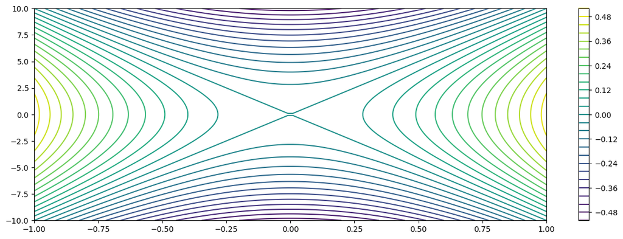

```python
# Script for question 1 - Plotting the quadratic function in dimension 2

d = 2
lbda = 0.01

# Defining the matrix H and the quadratic problem
H = np.eye(d)
H[d-1,d-1] = -lbda


# Plot countours of the objective function over a subdomain containing 0
delta = 10
x1 = np.linspace(-1,1,100)
x2 = np.linspace(-delta,delta,100)
fx = [[0.5*np.array([u1,u2]).dot(H.dot(np.array([u1,u2]))) for u1 in x1] for u2 in x2]
plt.figure(figsize=(15,5))
plt.contour(x1,x2,fx,levels=30)
plt.colorbar()
```

#### Observations

*The origin is a minimum along the horizontal axis, but a maximum along the vertical axis.*

*More generally, in dimension $d$, consider $\mathbf{u}=\epsilon\mathbf{e}_1$ (first vector of the canonical basis in $\mathbb{R}^d$) and $\mathbf{v}=\epsilon\mathbf{e}_d$ (last vector of the canonical basis in $\mathbb{R}^d$). Then $\|\mathbf{u}\|=\|\mathbf{v}\|=\epsilon$. Moreover, using that $\mathbf{H}\mathbf{e}_1=\mathbf{e}_1$ by definition of $\mathbf{H}$, we obtain $$ q(\mathbf{u})=\frac{1}{2}\mathbf{u}^T \mathbf{H} \mathbf{u} = \frac{\epsilon^2}{2}\mathbf{e}_1^T \mathbf{H} \mathbf{e}_1 = \frac{\epsilon^2}{2}\|e_1\|^2 = \frac{\epsilon^2}{2} > 0. $$ Similarly, using $\mathbf{H}\mathbf{e}_d=-\lambda \mathbf{e}_d$ yields $q(\mathbf{v})=-\frac{\lambda\epsilon^2}{2}<0$.*

In the code below, we use a bunch of initial points and check whether gradient descent converges to the saddle point $\mathbf{0}$ or manages to escape that saddle point, in the sense that it computes $\mathbf{w}_k$ such that $q(\mathbf{w}_k)<0$.

The script below:

- Launches gradient descent from 100 different starting points and checks how many escape the saddle point.
- Includes (with the right flag) a point for which gradient descent converges to the saddle point.

```
GD escaped the saddle point  100  times out of  101  random trials
GD failed on the manually chosen starting point
```

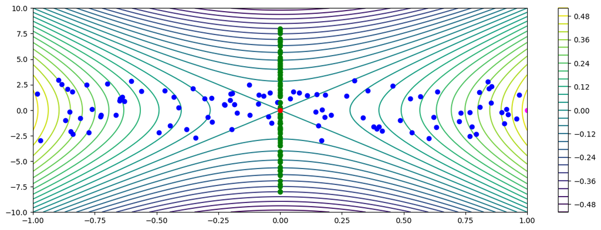

```python
# Script - Gradient descent on nonconvex quadratics
###############################################################################

d = 2
lbda = 0.01

# Defining the matrix H and the quadratic problem
H = np.eye(d)
H[d-1,d-1] = -lbda
L=1 #Lipschitz constant


# Draw a bunch of random points and plot the result
ntrials = 100
w_min_lin = np.zeros(d)

# Boolean to introduce a known point of failure for the method
failpt = True
# Define initial points and final values according to the boolean
if failpt:
    W0 = np.zeros((ntrials+1,d))
    Wf = np.zeros((ntrials+1,d))
    vf = np.zeros(ntrials+1)
else:
    W0 = np.zeros((ntrials,d))
    Wf = np.zeros((ntrials,d))
    vf = np.zeros(ntrials)

# Counting the number of "good trials" (those for which GD escaped the saddle point)
goodtrials = 0

# Run multiple instances of GD
for i in range(ntrials):
    W0[i,:] = uniform([-1,-3],[1,3],size=d) # Sampling box chosen for display purposes
    Wf[i,:], obj_q = gd_quad(W0[i,:],H,1/L, n_iter=100,verbose=False)
    vf[i] = obj_q[-1]
    if vf[i]<0:
        goodtrials += 1

# Add a point of failure for GD
if failpt:
    #
    W0[ntrials,:]= np.ones(d)
    W0[ntrials,-1] = 0 # Remove the component in the negative eigenspace
    #
    Wf[ntrials,:], obj_q = gd_quad(W0[ntrials,:],H,1/L, n_iter=100,verbose=False)
    vf[ntrials] = obj_q[-1]
    if vf[ntrials]<0:
        goodfailpt = 1
    else:
        goodfailpt = 0

print('GD escaped the saddle point ',goodtrials,' times out of ', ntrials+1,' random trials')
if failpt:
    if goodfailpt:
        print('GD succeeded on the manually chosen starting point')
    else:
        print('GD failed on the manually chosen starting point')

# Plot the results if dimension allows it
if d==2:
    npts = vf.size
    plt.figure(figsize=(15,5))
    plt.contour(x1,x2,fx,levels=30)
    plt.colorbar()
    for i in range(npts):
        if vf[i]<0:
            plt.plot(W0[i,0],W0[i,1],'o',color='blue')
            plt.plot(Wf[i,0],Wf[i,1],'o',color='green')
        else:
            plt.plot(W0[i,0],W0[i,1],'o',color='magenta')
            plt.plot(Wf[i,0],Wf[i,1],'o',color='red')
```

#### Observations

1. When the runs start from a randomly generated point (blue dots), one sees that they end up at a point with better function value than the origin (green dots). This means that these runs have escaped the saddle point, thus confirming that gradient descent almost always avoids such a point.
2. When one considers the point $\mathbf{w}_0 \in \mathrm{span}\{\mathbf{e}_1,\dots,\mathbf{e}_{d-1}\}$ (purple dot), i.e. with last coordinate equal to $\mathbf{0}$, gradient descent will always converge to the saddle point, because this point is optimal with respect to the first $d-1$ coordinates. Indeed, the iterative process of gradient descent with stepsize $\frac{1}{L}=1$ gives $$ \mathbf{w}_1 = \mathbf{w}_0 - \nabla q(\mathbf{w}_0)=\mathbf{w}_0-\mathbf{w}_0=\mathbf{0}. $$ This is what we observe on the plot. When started at $\mathbf{w}_0$ in dimension 2 (purple dot), the method reaches the origin (red dot), which is a saddle point. It is thus possible to find situations in which gradient descent converges to a saddle point (but again, these situations *almost never* happen!).

# Part 3 - Gradient descent for matrix problems

In this section, we apply gradient descent to a nonconvex optimization formulation derived from the low-rank matrix completion setting. This function does not satisfy the assumptions of the "almost-sure convergence" theorem, however we will see that similar observations apply.

## 3.1 Problem data

We consider a data matrix $\mathbf{M} \in \mathbb{R}^{d \times d}$ assumed to be symmetric positive semidefinite and low rank, which means that the number of positive eigenvalues of $\mathbf{M}$ is $r \ll d$, all the other eigenvalues being $0$. Given a limited number of observations $s$ of $\mathbf{M}$, our goal is to find an approximation of this matrix.

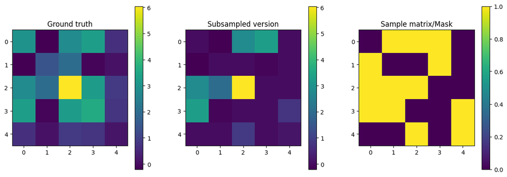

```python
d = 5 # Matrix size is d*d
r = 2 # Intrisic rank
nb_s = 13 # Number of observed entries

# Fix random seed for reproducibility
np.random.seed(1)

M,S,M_sampled,U = datamatrix(d,r,nb_s)


# Plot the results
plt.figure(figsize=(15,5))
plt.get_cmap('twilight')
plt.subplot(131)
plt.title('Ground truth')
plt.imshow(M)
plt.colorbar()
plt.subplot(132)
plt.title('Subsampled version')
plt.imshow(M_sampled)
plt.colorbar()
plt.subplot(133)
plt.title('Sample matrix/Mask')
plt.imshow(S)
plt.colorbar()
```

## 3.2 Nonconvex formulation and derivatives

We now focus on a nonconvex formulation of this problem. The classical, convex optimization approach consists in solving $$ \mathrm{minimize}_{\mathbf{W} \in \mathbb{R}^{d \times d}} \frac{1}{2} \sum_{(i,j) \in \mathcal{S}} \left( \mathbf{W}_{ij}-\mathbf{M}_{ij}\right)^2 $$ where $\mathcal{S} \subset \{1,\dots,d\}^2$ represents the set of entries of the data matrix $\mathbf{M}$ that are observed. This problem is convex, but requires the manipulation of a $d \times d$ matrix. In addition, the solution need not be low rank: in fact, to guarantee that the solution will possess the same properties add the constraint $\mathrm{rank}(\mathbf{W})=r$ in order for the problem to guarantee a low-rank approximation, plus a constraint of the form $\mathbf{W} \succeq \mathbf{0}$ to guarantee that $\mathbf{W}$ has (like $\mathbf{M}$) only nonnegative eigenvalues.

Overall, the problem we should look at is $$ \mathrm{minimize}_{\mathbf{W} \in \mathbb{R}^{d \times d}} \frac{1}{2} \sum_{(i,j) \in \mathcal{S}} \left( \mathbf{W}_{ij}-\mathbf{M}_{ij}\right)^2 \quad \mathrm{subject\ to} \quad \mathbf{W}=\mathbf{W}^T \succeq \mathbf{0},\ \mathrm{rank}(\mathbf{X}) \le r. $$

Instead of this formulation, we adopt the Burer-Monteiro approach and reformulate the problem using a factored representation of the problem variable $\mathbf{W}$ that highlights its low-rank structure. This leads to the following formulation: $$ \mathrm{minimize}_{\mathbf{U} \in \mathbb{R}^{d \times r}} \frac{1}{2}\sum_{(i,j) \in \mathcal{S}} \left( [\mathbf{U}\mathbf{U}^T]_{ij}-\mathbf{M}_{ij}\right)^2. $$ Compared to the original formulation, our approximation of $\mathbf{M}$ is given by $\mathbf{U}\mathbf{U}^T$, which is by construction a rank-$r$ matrix, *but we only solve the problem in $\mathbf{U} \in \mathbb{R}^{d \times r}$*. This problem is unconstrained in $\mathbf{U}$ and involves only $dr$ variables by explicitly enforcing the low-rank property.

We would like to apply gradient descent to the following problem $$ \mathrm{minimize}_{\mathbf{U} \in \mathbb{R}^{d \times r}}\ f(\mathbf{U}):= \frac{1}{2}\sum_{(i,j) \in \mathcal{S}} \left([\mathbf{U}\mathbf{U}^T]_{ij}-\mathbf{M}_{ij}\right)^2 $$ There are two ways to approach this problem: the first one consists in viewing this problem as one on $\mathbb{R}^{dr}$, and do a standard gradient descent procedure. This approach allows for reusing our generic gradient descent code from above.

The second approach preserves the matrix structure of the variables, and defines the gradient of $f$ as a matrix in $\mathbb{R}^{d \times r}$ (similarly to the vector case, in which $\nabla \phi(\mathbf{x}) \in \mathbb{R}^d$ for any function $\phi: \mathbb{R}^d \rightarrow \mathbb{R}$ and $\mathbf{x} \in \mathbb{R}^d$). In our case, we define the gradient of $f$ with respect to any $\mathbf{U} \in \mathbb{R}^{d \times r}$ as: $$ \nabla f(\mathbf{U}) := (\mathbf{E}+\mathbf{E}^T)\mathbf{U} \quad \text{where} \quad \mathbf{E}:= (\mathbf{U}\mathbf{U}^T-\mathbf{M}) \otimes \mathbf{S}, $$ with $\otimes$ denoting the Hadamard/entrywise matrix product, and $\mathbf{S} \in \mathbb{R}^{d \times d}$ is defined by

$$ \mathbf{S}_{ij} = \left\{ \begin{array}{ll} 1 &\text{if $(i,j) \in \mathcal{S}$} \\ 0 &\text{otherwise.} \end{array} \right. $$

The two functions in the next block use this approach to encode the function value and its derivative.

```python
# Objective function for the nonconvex matrix factorization problem
def f_mat(U,M_S,S):
    '''
        Function value for the low-rank matrix factorization problem.
        The solution of this problem is a matrix U such that U*U^T agrees as best as possible with M_S on its
        non-zero entries.

        Inputs:
            U: d-by-r matrix (decision variables)
            M_S: Samples from the data matrix
            S: Sampling pattern

        Output:
            f: Value of the low-rank matrix functional at U
    '''
    E = np.dot(U,np.transpose(U))-M_S
    E = E * S
    return 0.5*np.sum(E**2)

# Objective and gradient vector for the nonconvex matrix factorization problem
def fg_mat(U,M_S,S):
    '''
        Objective and gradient vector for the low-rank matrix factorization problem.
        The solution of this problem is a matrix U such that U*U^T agrees as best as possible with M_S on its
        non-zero entries.

        Inputs:
            U: d-by-r matrix (decision variables)
            M_S: Samples from the data matrix
            S: Sampling pattern

        Output:
            f: Value of the low-rank matrix functional at U
            G: Value of the gradient of this functional (defined in a matrix sense) at U
    '''
    E = np.dot(U,np.transpose(U))-M_S
    E = E * S
    f = 0.5*np.sum(E**2)
    G = np.dot(E+np.transpose(E),U)
    return f,G
```

The *ad hoc* version of gradient descent for the low-rank matrix completion problem is given below. Note that it computes an adaptive stepsize through a backtracking line search procedure.

```python
def gd_matrix(U0,fun,fungrad,f_base,step,linesearch=False,n_iter=10000, verbose=False):
    """
        A code for gradient descent on low-rank matrix-type problems.

        Inputs:
            U0: Initial (rectangular) matrix
            fun: Objective function, returns f(U) for every U
            fungrad: Returns both the objective function and its gradient
            f_base: A base value to assess convergence
            step: Initial value of the stepsize
            linesearch: Boolean indicating whether or not a line search should be performed
            n_iter: Number of iterations
            verbose: Boolean value indicating whether the outcome of every iteration should be displayed

        Outputs:
            U_output: Final iterate of the method
            objvals: History of function values (output as a Numpy array of length at most n_iter+1)
            ngvals: History of gradient norms (output as a Numpy array of length at most n_iter+1)
            nits: Number of iterations actually performed
            flag: Termination flag
                0: Convergence in terms of function value (decrease of f_base by 1e-4)
                1: Convergence in terms of gradient norm (below 1e-3, normalized by norm(U_output))
                2: Maximum number of iterations reached

    """

    ############
    # Initial step: Compute and plot some initial quantities

    # objective history
    objvals = []

    # gradient norm history
    ngvals = []

    # Initial value of current iterate
    U = U0.copy()

    # Initialize iteration counter
    k=0

    # Current objective and gradient value
    obj,G = fungrad(U)
    objvals.append(obj)
    ngrad = norm(G)
    ngvals.append(ngrad)

    # Plot the initial values if asked to
    if verbose:
        print("Gradient Descent:")
        print(' | '.join([name.center(8) for name in ["iter", "fval", "ngrad"]]))
        print(' | '.join([("%d" % k).rjust(8),("%.2e" % obj).rjust(8),("%.2e" % ngrad).rjust(8)]))

    # Stopping boolean
    if (obj<=1e-4*f_base):
        flag=0
    elif (ngrad<=1e-3*norm(U)):
        flag=1
    else:
        flag=2

    stopping=(flag==2)

    ####################
    # Main loop
    while stopping:

        # Select the stepsize and perform the update
        if linesearch:
            if k>0:
                step = 1.1*step
            fval = fun(U-step*G)
            ngrad2 = ngrad**2
            # Loop to increase the value of L if necessary
            while (fval-obj>-0.5*step*ngrad2):
                step = step/2
                fval = fun(U-step*G)

        U = U - step * G

        # Compute the new objective and gradient
        obj,G = fungrad(U)
        objvals.append(obj)
        ngrad = norm(G)
        ngvals.append(ngrad)

        # Plot relevant information if asked to
        if verbose:
            print(' | '.join([("%d" % k).rjust(8),("%.2e" % obj).rjust(8),("%.2e" % ngrad).rjust(8)]))

        # Increment the iteration count
        k += 1

        # Stopping boolean
        if (obj<=1e-4*f_base):
            flag=0
        elif (ngrad<=1e-3*norm(U)):
            flag=1
        else:
            flag=2
        stopping = (flag==2)

    # End main loop
    ######################

    # Output
    U_output = U.copy()
    nits = k

    return U_output, np.array(objvals), np.array(ngvals),nits,flag
```

We can run this method on a small-scale example and observe that it does provide a good candidate solution.

```
Objective function: 3.294970662944837e-05
Normalized gradient norm: 0.016902753742291565
```

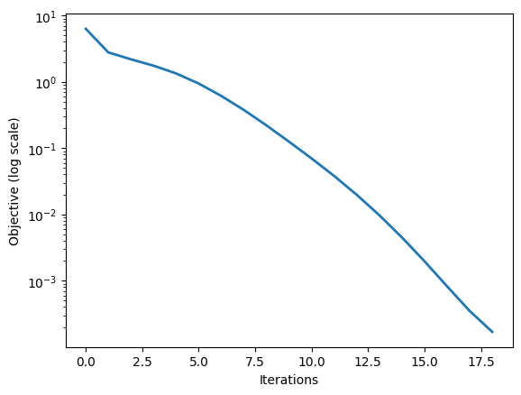

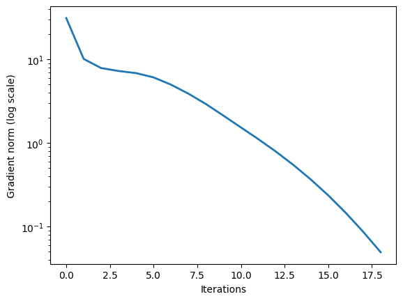

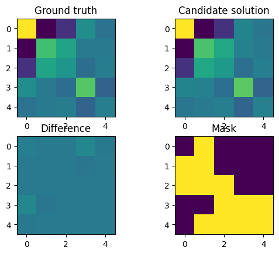

```python
# Validation on a small-dimensional example

d=5
r=2
nb_s=13

M,S,M_s,U_star = datamatrix(d,r,nb_s)

fbase = 0.5*(np.sum(M_s**2))

# Run gradient descent
U0 = randn(d,r)
U_out,obj_out,ng_out,nits,flag = gd_matrix(
    U0,lambda U: f_mat(U,M_s,S),lambda U: fg_mat(U,M_s,S),fbase,1.,True,10000,False)


# Plot the results
print("Objective function:",obj_out[-1]/(norm(M_s)**2))
print("Normalized gradient norm:",ng_out[-1]/norm(U_out))
M_out = np.dot(U_out,np.transpose(U_out))

plt.figure(1)
plt.semilogy(obj_out/norm(M_s), lw=2)
plt.xlabel('Iterations')
plt.ylabel('Objective (log scale)')
plt.figure(2)
plt.semilogy(ng_out, lw=2)
plt.xlabel('Iterations')
plt.ylabel('Gradient norm (log scale)')
plt.figure(3)
plt.subplot(221)
plt.title('Ground truth')
plt.imshow(M)
plt.subplot(222)
plt.title('Candidate solution')
plt.imshow(M_out,vmin=np.amin(M_out),vmax=np.amax(M_out))
plt.subplot(223)
plt.title('Difference')
plt.imshow(M-M_out,vmin=np.amin(M_out),vmax=np.amax(M_out))
plt.subplot(224)
plt.title('Mask')
plt.imshow(S)
```

We now consider running gradient descent on multiple instances of this problem (i.e. use multiple data matrices). For any instance, we consider that

- GD converges to a solution if the final function value is below $10^{-4}\|\mathbf{M}_S\|^2$;
- GD converges to a critical point but not a solution if the previous test fails but the final gradient norm is below $10^{-3}\|\mathbf{U}_K\|$, where $\mathbf{U}_K$ is the last iterate;
- GD fails to converge otherwise.

We compare below the number of solved/converged/failed instances as we increase the number of observations.

```
10 Samples out of 81
12 Samples out of 81
14 Samples out of 81
16 Samples out of 81
18 Samples out of 81
20 Samples out of 81
22 Samples out of 81
24 Samples out of 81
26 Samples out of 81
28 Samples out of 81
30 Samples out of 81
32 Samples out of 81
34 Samples out of 81
36 Samples out of 81
38 Samples out of 81
40 Samples out of 81
42 Samples out of 81
```

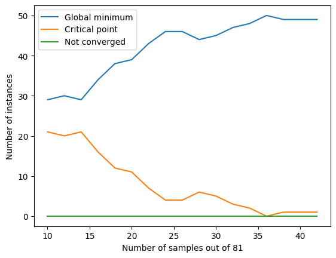

```python
# Implementation - Running multiple instances

d=9
r=1
vals_s = range(10,44,2)
len_s = len(vals_s)
counter = np.zeros((len_s,3))
#
for n_it in range(0,len_s):
    nb_s = vals_s[n_it]
    print(str(nb_s) + ' Samples out of '+str(d**2)),
    for i in range(0,50):
        M,S,M_s,U_star = datamatrix(d,r,nb_s)
        nMs2 = 0.5*norm(M_s)**2
        U0 = randn(d,r)
        U_out,obj_out,ng_out,_,flag = gd_matrix(U0,lambda U: f_mat(U,M_s,S),lambda U: fg_mat(U,M_s,S),nMs2,1.,True,20000,False)
        counter[n_it,flag]+=1
#
plt.xlabel('Number of samples out of '+str(d**2))
plt.ylabel('Number of instances')
plt.plot(vals_s,counter[:,0],label='Global minimum')
plt.plot(vals_s,counter[:,1],label='Critical point')
plt.plot(vals_s,counter[:,2],label='Not converged')
plt.legend()
```

#### Takeaways from the experiment

As the number of samples increases, gradient descent appears to converge more often to global minima than other critical points. This suggests that the spurious critical points disappear as the number of samples increases, and the number of degrees of freedom for a critical point decreases.